# Measuring shape with the Euler Characteristic $\chi$

## Erik Amézquita

Dept of Computational Mathematics, Science & Engineering

Michigan State University

March 2021

[Part of the AATRN Tutorial-a-thon](https://sites.google.com/view/aatrn-tutorial-a-thon)

# Quantify and compare all shape diversity

- Data diversity: morphometrics might not be enough

```python
display.display(widgets.HBox([video1,video2,video3,video4]))
```

```
HBox(children=(Output(outputs=({'output_type': 'display_data', 'data': {'text/plain': '<IPython.lib.display.Yo…
```

# Topological Data Analysis

### Shape is data, and data is shape

[figure not shown]

**Raw Data**

- X-ray CT
- Point clouds
- Time series

**Topological Summary**

- Euler Characteristic
- Persistence diagrams
- Mapper/Reeb graphs

**Analysis**

- Statistics
- Machine learning
- Classification/prediction

# Two basic ingredients to do TDA

## 1. Data points / Network / Image → Complexes

**Cubical complex**

- 2 connected components
- 3 loops
- 1 void
- TDA seeks to describe the **shape** of data based on important **topological features**:
  - Connected components
  - Loops
  - Voids.

## 2. Filter function: point / pixel → real number

| **Curvature** | **Eccentricity** | **Gaussian Density** | **Vietoris-Rips** |
| --- | --- | --- | --- |

TDA seeks to describe how the topological **features** (number of connected components, loops, voids) **change** as we increase the filter values.

# The Euler Characteristic $\chi$

- Topological **invariant**: Objets with the same topological features will share the **same** Euler Characteristic

$$\chi = \#({\rm Vertices}) - \#({\rm Edges}) + \#({\rm Faces})$$

[figure not shown]

- Euler-Poincaré formula:

$$\chi = \#(\text{Connected Components}) - \#({\rm Loops}) + \#({\rm Voids})$$

# The Euler Characteristic Curve (ECC)

- Pick a **direction**. (Directional filter)
- Slice the image into a fixed number of slices (**thresholds**) along the initial direction.
- Keep track of **changes** in $\chi$ as we reconstruct the image, one slice at a time.

[figure not shown]

# The Euler Characteristic Transform (ECT)

- Perform the ECC with **all possible** directions
- **Concatenate** all resulting ECCs

[figure not shown]

# Importance of the ECT

- **Computationally extremely efficient** (as you'll see in the examples below)
- **Mathematically** speaking, the ECT is a **sufficient** shape statistic
- *Caveat:* We do need an **infinite** number of directions for the math to hold.

# Let's see an example!

Make sure to check the README in the repository to know how to install `demeter`

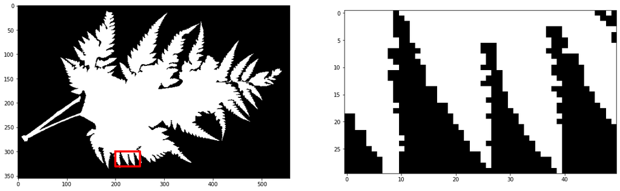

```python
leaf_file = '../example_data/leafbw.tif'
leaf_img = tf.imread(leaf_file).T
leaf_img[leaf_img > 0] = 1
#leaf_img = ndimage.binary_closing(leaf_img, iterations=2)
leaf_img = ndimage.binary_fill_holes(leaf_img).astype(leaf_img.dtype)

fig, ax = plt.subplots(1,2,figsize=(20,6))
ax[0].imshow(leaf_img, cmap='gray');
ax[0].plot([200,200,250,250,200], [300,330,330,300,300], c='red', lw=4);
ax[1].imshow(leaf_img[300:330, 200:250], cmap='gray');
```

# Choose directions

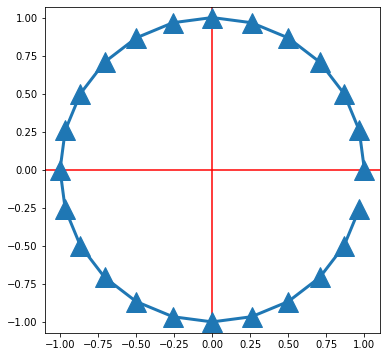

```python
circle_dirs = dirs.regular_directions(24, dims=leaf.ndim)
plt.figure(figsize=(6,6))
plt.axhline(0, color='red')
plt.axvline(0, color='red')
plt.plot(circle_dirs[:,0], circle_dirs[:,1], marker='^', ms=20, lw=3)
plt.axis('equal');
```

# Compute the Euler Characteristic Curve (ECC) along one direction

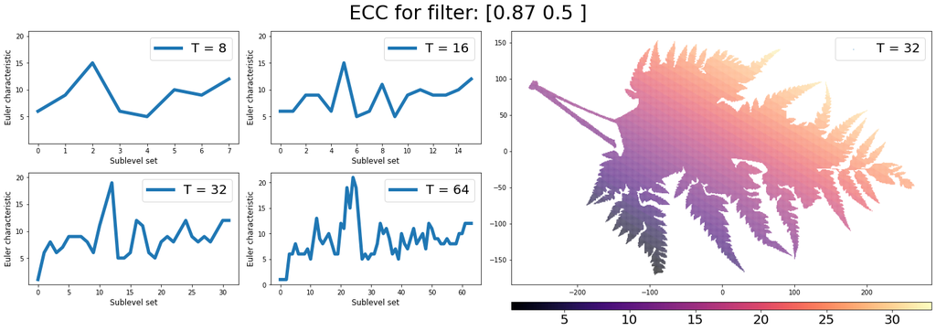

```python
T = [8,16,32,64,128]
i = 2
direction = circle_dirs[i, :]
heights = np.sum(leaf.cells[0]*direction, axis=1)
plot_ecc_filtration(leaf, heights, T, title=np.around(direction,2), ylim=(1,20))
```

# Concatenate to get the Euler Characteristic Transform (ECT)

```
Complex with 64930 vertices

ECT with 24 directions in 0.2969 seconds.
0.0124s per direction
```

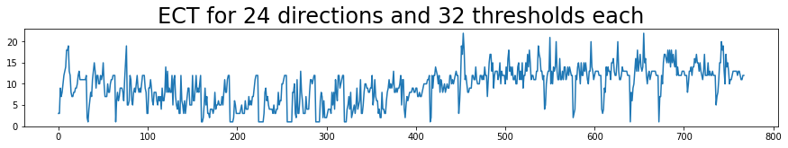

```python
t = 32
tic = time.perf_counter()
ect = leaf.ECT(circle_dirs, T=t)
toc = time.perf_counter()
print("Complex with {} vertices\n".format(len(leaf.cells[0])))
print("ECT with {} directions in {:.4f} seconds.\n{:.4f}s per direction".format(len(circle_dirs), toc-tic, (toc-tic)/len(circle_dirs)))

plt.figure(figsize=(15,2))
plt.plot(ect);
plt.title('ECT for {} directions and {} thresholds each'.format(len(circle_dirs),t), fontsize=24);
```

## Even more filters

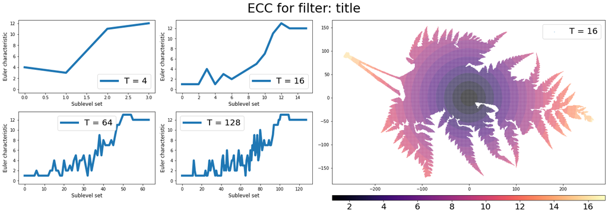

```python
T = [4,16,64,128]
filtration = radial_distance(leaf.cells[0])
ylim = (0,12)
#T = [4,8,16,32]
#filtration = distance_transform(leaf.img)
#ylim = (-10,15)

plot_ecc_filtration(leaf, filtration, T, TT=16, ylim=ylim)
```

# What next?

- Every shape can be translated to a vector of topological features
- You can try to do standard statistics and data analysis

## Go crazy!

- Experiment with different number of directions
- And different ways to define directions
- What other filter functions can you think of?

## Tutorial notebook available

- Download this notebook from the [github repo](https://github.com/amezqui3/demeter/tutorial): `https://github.com/amezqui3/demeter/tutorial/`

# Thank you!

- Joint work with [Dan Chitwood](https://dhchitwood.wixsite.com/morphologylab/publications) and [Liz Munch](http://www.elizabethmunch.com/) at CMSE/Horticulture/Math @ Michigan State University
- Image processing/computational tips from [Tim Ophelders](https://www.win.tue.nl/~tophelde/)
- X-ray CT scans done by [Michelle Quigley](https://www.canr.msu.edu/people/michelle-quigley)
- Barley seeds generously provided by [Dan Koenig](https://koeniglab.com/) and [Jacob Landis](https://jacoblandis.com/)
- Citrus generously provided by [Danelle Seymour](https://www.seymour-lab.com/)
- Fern leaf 2D scan courtesy of [Rebecca Dikow](https://datascience.si.edu/people/dr-rebecca-dikow) and [Alexander White](http://www.alexwhitebiology.com/).

| amezqui3@msu.edu | egr.msu.edu/~amezqui3 |  |  |
| --- | --- | --- | --- |